# Coursera Maschine Learning Assignment

by Christoph

2 Dezember 2016

## Introduction

In this document I will describe how I used data from “http://groupware.les.inf.puc-rio.br/har”" to build a model for predicting barbell lifts quality based on data measured by accelerometers. The quality is measured in 5 different classes A:E.

Training data: https://d396qusza40orc.cloudfront.net/predmachlearn/pml-training.csv

Testset: https://d396qusza40orc.cloudfront.net/predmachlearn/pml-testing.csv

```r
basedata <- read.csv("pml-training.csv", na.strings = c(""," ", "NA"), stringsAsFactors=F)
basedata$classe <- as.factor(basedata$classe)
```

## Some data exploration

Checking for the amount of rows and columns

```r
dim(basedata)
```

```
## [1] 19622   160
```

Some histogram to check out how classes and users are split:

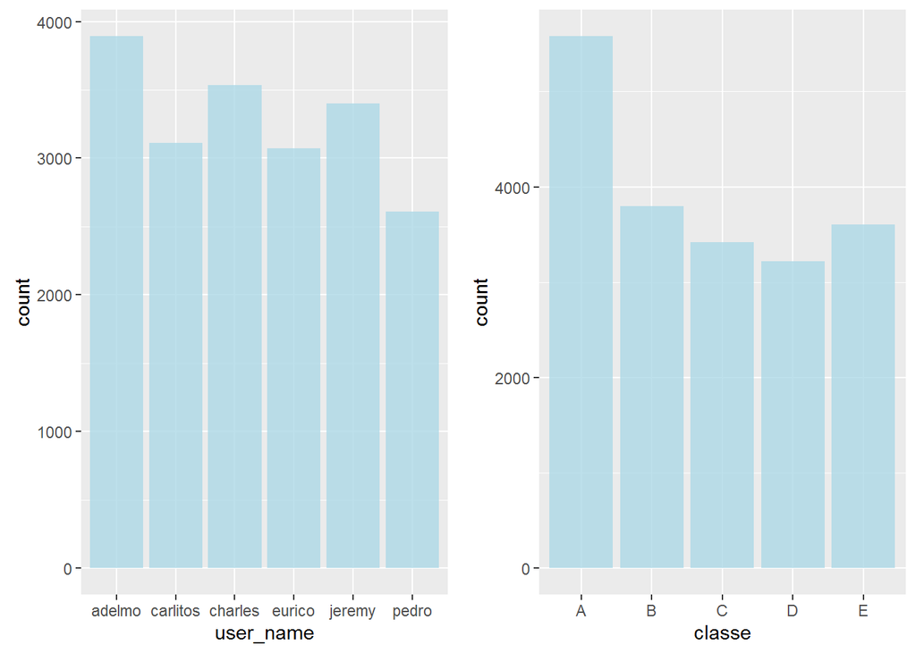

```r
g1 <- ggplot(aes(user_name), data = basedata) + geom_bar(alpha=0.8, fill="lightblue")
g2 <- ggplot(aes(classe), data = basedata) + geom_bar(alpha=0.8, fill="lightblue")
grid.arrange(g1, g2, ncol=2)
```

Checking for “na” columns:

```r
sapply(basedata, function(y) sum(length(which(is.na(y)))))
```

[output not shown]

[output cut: 53 more lines]

[output not shown]

Obviously there are many columns with a huge amount of “na”. These will be excluded before starting the model evaluation, as they won’t bring any value due to the low variance.

```r
basedata <- basedata[ , !colSums(is.na(basedata)) > 19000]
head(basedata[,1:7])
```

```
##   X user_name raw_timestamp_part_1 raw_timestamp_part_2   cvtd_timestamp
## 1 1  carlitos           1323084231               788290 05/12/2011 11:23
## 2 2  carlitos           1323084231               808298 05/12/2011 11:23
## 3 3  carlitos           1323084231               820366 05/12/2011 11:23
## 4 4  carlitos           1323084232               120339 05/12/2011 11:23
## 5 5  carlitos           1323084232               196328 05/12/2011 11:23
## 6 6  carlitos           1323084232               304277 05/12/2011 11:23
##   new_window num_window
## 1         no         11
## 2         no         11
## 3         no         11
## 4         no         12
## 5         no         12
## 6         no         12
```

```r
basedata <- basedata[ , -c(1:7)]
```

Additionally the first 7 columns will also be excluded, as the are not related to measurements of the accelerometers.

## Model selection

1. The remaining dataset was split into a training and a testing set.
2. Three different maschine learning algorithms were applied.
3. Running a prediction against the testing set.
4. Calculating the accuracy with the predicted values vs. the actual values.

```r
inTrain <- createDataPartition(y=basedata$classe, p=0.75,list=F)
training <- basedata[inTrain,]
testing <- basedata[-inTrain,]
```

As especially the boosting and random forest algorithm ran very long, I show the commented code only and present the result of the accuracy calculation.

```r
# modFit <- train(classe~.,method="rpart", data=training)
# modFit <- train(classe~.,method="rf", data=training)
# modFit <- train(classe~.,method="gbm", data=training)

# predValues <- predict(modFit,testing)
# accur <- sum(predValues == testing$classe) / dim(testing)[1]

# print(paste("Accuracy: ", accur))
```

The results for the different model were:

*TREE* = **0.49** | *RANDOM FOREST* = **0.99** | *BOOSTING* = **0.96**

Obviously “Random Forest” gives the best results.

## Predicting the test data

This code can only be executed on my computer, as I stored the result of the model fit for random forest in an object on my disc.

```r
testcases <- read.csv("pml-testing.csv", na.strings = c(""," ", "NA"), stringsAsFactors=F)
load(file="rfModelFit.rfmodel")
predict(modFit, newdata = testcases)
```

```
##  [1] B A B A A E D B A A B C B A E E A B B B
## Levels: A B C D E
```